# HW3 - DATA 609

Thomas Hill

October 3, 2021

```r
library(stats)
library(optimr)
```

**Ex. 1** – Write down Newton’s formula for finding the minimum of $f(x) = \frac{3x^4 - 4x^3}{12}$ in the range of [-10,10]. Then, implement in R.

Newton’s method of finding the minimum or maximum value of a function, f(x), is by solving the formula

$$x_{k+1} = x_k - \frac{g(x_k)}{g'(x_k)} = x_k - \frac{g'(x_k)}{g''(x_k)}$$

where $g(x) = f'(x) = 0$. Since we’re looking at the range [-10, 10], we can use the start point of -10 and increasing, or 10 and decreasing.

```r
function_1 <- expression((3*x^4 - 4*x^3)/12)

g_x <- D(function_1,"x")

g_x
```

```
## (3 * (4 * x^3) - 4 * (3 * x^2))/12
```

```r
deriv_g_x <- D(g_x,"x")

deriv_g_x
```

```
## (3 * (4 * (3 * x^2)) - 4 * (3 * (2 * x)))/12
```

It’s clear from g(x) that there’s at least one zero at x = 0. Factoring also gives the following:

$$x^3 - x^2 = x^2(x-1)$$

```r
ex_1_newton <- function(x_k) {

  result <- x_k - ((3 * (4 * x_k^3) - 4 * (3 * x_k^2))/12)/((3 * (4 * (3 * x_k^2)) - 4 * (3 * (2 * x_k)))/12)
  return((result))
}





ex_1_newton(ex_1_newton(ex_1_newton(ex_1_newton(ex_1_newton(ex_1_newton(ex_1_newton(ex_1_newton(10))))))))
```

```
## [1] 1.01487
```

```r
ex_1_newton(ex_1_newton(ex_1_newton(ex_1_newton(ex_1_newton(ex_1_newton(ex_1_newton(ex_1_newton(ex_1_newton(ex_1_newton(ex_1_newton(ex_1_newton(ex_1_newton(-10)))))))))))))
```

```
## [1] -0.007949901
```

Iterating through these several times brings us very close to the two zeroes. However, let’s try doing the same thing between [0,1]

```r
ex_1_newton(ex_1_newton(ex_1_newton(ex_1_newton(ex_1_newton(ex_1_newton(ex_1_newton(ex_1_newton(ex_1_newton(0.4)))))))))
```

```
## [1] 0.0003501794
```

```r
ex_1_newton(ex_1_newton(ex_1_newton(ex_1_newton(ex_1_newton(ex_1_newton(ex_1_newton(ex_1_newton(ex_1_newton(0.75)))))))))
```

```
## [1] 1
```

Between these two points, we are also given two different answers. So, it appears that Newton’s method is unable converge at a single minimum over this range.

**Ex. 2** – Explore *optimize()* in R and try to solve the previous problem.

```r
ex_2_function <- function(x) {
  (3*x^4 - 4*x^3)/12
}

optimize(ex_2_function, c(-10,10))
```

```
## $minimum
## [1] 0.9999986
##
## $objective
## [1] -0.08333333
```

Using the built-in function R, a single value is returned with no errors raised.

**Ex. 3** – Use any optimization algorithm to find the minimum of $f(x,y) = (x-1)^2 + 100(y - x^2)^2$ in the domain $-10\leq x, y \leq 10$. Discuss any issues concerning the optimization process.

```r
ex_3_F <- expression((x-1)^2 + 100*(y- (x)^2)^2)

g_x3 <- D(ex_3_F,"x")

g_xy3 <- D(g_x3, 'y')
g_xx3 <- D(g_x3, 'x')

g_y3 <-  D(ex_3_F,"y")

g_yx3 <- D(g_y3, 'x')
g_yy3 <- D(g_y3, 'y')

print(g_xx3)
```

```
## 2 - 100 * (2 * (2 * (y - (x)^2) - 2 * (x) * (2 * (x))))
```

```r
print(g_xy3)
```

```
## -(100 * (2 * (2 * (x))))
```

```r
print(g_yx3)
```

```
## -(100 * (2 * (2 * (x))))
```

```r
print(g_yy3)
```

```
## 100 * 2
```

The resulting Hessian is:

$$H = \begin {bmatrix}
1200x^2 -400y + 2 & -400x \\
-400x & 200
\end {bmatrix}$$

Its inverse is:

$$H^{-1} = \frac {1}{200(1200-x^2-400y+2)-(400x)^2} \begin {bmatrix}
200 & 400x \\
400x & 1200x^2 -400y + 2
\end {bmatrix}$$

and gradient:

$$\nabla f = \begin {bmatrix}
2x(x-1) + 100(y^2 - 2x^2y + x^4) \\
200(y-x^2)
\end {bmatrix}$$

```r
ex_3_newton <- function(mat_params) {
  x <- mat_params[1]
  y <- mat_params[2]
  newton <-matrix(c(x,y), nrow = 2) - (1/(200*(1200-x^2-400*y+2)-(400*x)^2)) * matrix(c(200, 400*x, 400*x, 1200*x^2 -400*y + 2), nrow = 2) %*% matrix(c(2*x*(x-1) + 100*(y^2 - 2*(x^2)*y + x^4),200*(y-x^2)), nrow = 2)
  return(newton)
  }
```

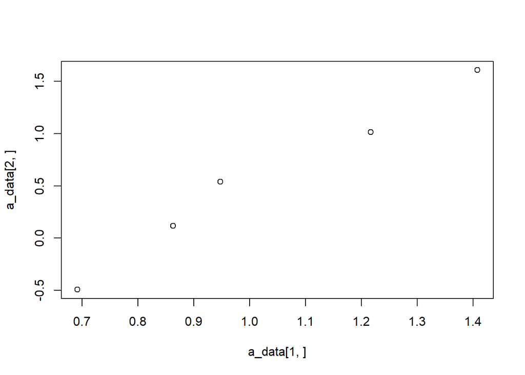

```r
a_1 <- ex_3_newton(c(1.2,1.2))
a_2 <-ex_3_newton(ex_3_newton(c(1.2,1.2)))
a_3 <- ex_3_newton(ex_3_newton(ex_3_newton(c(1.2,1.2))))
a_4 <-  ex_3_newton(ex_3_newton(ex_3_newton(ex_3_newton(c(1.2,1.2)))))
a_5 <- ex_3_newton(ex_3_newton(ex_3_newton(ex_3_newton(ex_3_newton(c(1.2,1.2))))))

a_data <- cbind(a_1,a_2,a_3,a_4,a_5)
plot(x = a_data[1,], y = a_data[2,])
```

This plot point does not converge to any of the minima.

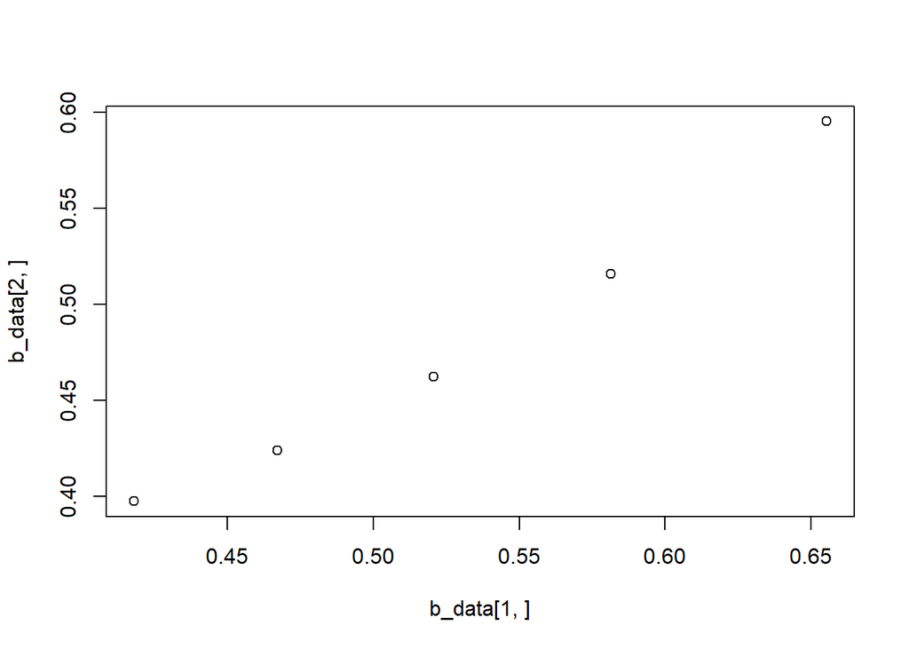

```r
b_1 <-ex_3_newton(c(0.8,0.8))
b_2 <- ex_3_newton(ex_3_newton(c(0.8,0.8)))
b_3 <- ex_3_newton(ex_3_newton(ex_3_newton(c(0.8,0.8))))
b_4 <- ex_3_newton(ex_3_newton(ex_3_newton(ex_3_newton(c(0.8,0.8)))))
b_5 <- ex_3_newton(ex_3_newton(ex_3_newton(ex_3_newton(ex_3_newton(c(0.8,0.8))))))



b_data <- cbind(b_1,b_2,b_3,b_4,b_5)
plot(x = b_data[1,], y = b_data[2,])
```

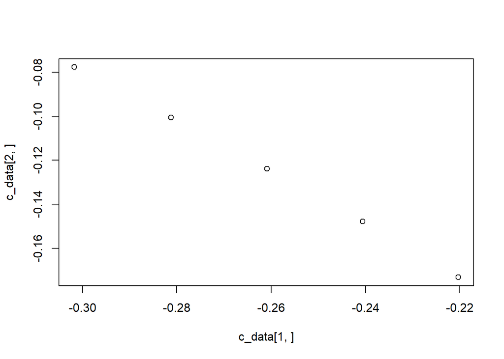

```r
c_1 <-ex_3_newton(c(-0.2,-0.2))
c_2 <- ex_3_newton(ex_3_newton(c(-0.2,-0.2)))
c_3 <- ex_3_newton(ex_3_newton(ex_3_newton(c(-0.2,-0.2))))
c_4 <- ex_3_newton(ex_3_newton(ex_3_newton(ex_3_newton(c(-0.2,-0.2)))))
c_5 <- ex_3_newton(ex_3_newton(ex_3_newton(ex_3_newton(ex_3_newton(c(-0.2,-0.2))))))

c_data <- cbind(c_1,c_2,c_3,c_4,c_5)
plot(x = c_data[1,], y = c_data[2,])
```

Looking at negative starting values, these also do not converge. It’s very obvious in the multivariable, unconstrained case that Newton’s method is unreliabile for finding minima.

**Ex. 4** – Expore the *optimr* package for R and try to solve the previous problem.

```r
ex_4_function <- function(para) {
  matrix.A <- matrix(para, ncol = 2) #matrix with values for x and y
  x <- matrix.A[,1]
  y <- matrix.A[,2]
  f.x <- (x-1)^2 + 100*(y - x^2)^2
  return(f.x)
}
```

```r
#par1 <- c(-10, -10)
#par2 <- c(-1, -1)
#par3 <- c(10, 10)
#par4 <- c(2.5,2.5)
par5 <- c(-2.5,-2.5)
par6 <- c(0.1,0.1)

#optimr(par = par1, fn = ex_4_function)
#optimr(par = par2, fn = ex_4_function)
#optimr(par = par3, fn = ex_4_function)
#optimr(par = par4, fn = ex_4_function)
optimr(par = par5, fn = ex_4_function)
```

```
## $par
## [1] 0.9974529 0.9947764
##
## $value
## [1] 8.333996e-06
##
## $counts
## function gradient
##       63       NA
##
## $convergence
## [1] 0
##
## $message
## NULL
```

```r
optimr(par = par6, fn = ex_4_function)
```

```
## $par
## [1] 0.9999909 0.9999783
##
## $value
## [1] 1.281042e-09
##
## $counts
## function gradient
##      135       NA
##
## $convergence
## [1] 0
##
## $message
## NULL
```

After some trial and error with starting points, it appears that optimr does find the solution at (1,1). However, some of the moe distant points (e.g, (10,10)) do not have enough iterations to converge on either point.